← AN05B023a/d scenes

# AN05B023a/d: sensory drive and downstream partners

## Setup

The same comparison as `05_an05b023bc.Rmd`, `07_an05b023cd.Rmd` and `10_an05b023ac.Rmd`, on the a/d pair. Everything that draws or fetches lives in `_an_pair.R`, so the pages cannot drift apart: only the pair, and what is said about it, is local to this file.

`rgl` cannot initialise headless on this machine, so `rgl.useNULL` is set before anything that might pull it in.

```r
options(rgl.useNULL = TRUE)   # must precede any library that pulls rgl in (nat)

suppressMessages({
  library(neuprintr); library(malecns); library(nat)
  options(malecns.dataset = "male-cns:v1.0")   # malecns helpers ignore MCNS_DATASET
  library(coconatfly); library(coconat)
  library(dplyr); library(tibble)
  library(ggplot2); library(ggrepel); library(scales); library(patchwork)
})

R_DIR <- "/Users/fkampf/Documents/pheromone.paper/analyses/an_investigation/R"

# AN_CASE may already be set to another case from an earlier 01-03 run in this
# session, so pin it rather than relying on the fallback in _paths.R.
Sys.setenv(AN_CASE = "an05b023ad")
source(file.path(R_DIR, "_paths.R"))
source(file.path(R_DIR, "_an_pair.R"))
neuprint_login(server = MCNS_SERVER, dataset = MCNS_DATASET)

PAIR <- TARGET_TYPES   # left of zero, right of zero
PAIR
```

```
## [1] "AN05B023a" "AN05B023d"
```

Annotation tables are expensive to fetch, so they are cached in the global environment for the session.

```r
load_once <- function(name, expr, envir = .GlobalEnv) {
  # eval() here evaluates a quote()d expression written literally in this file -
  # it is a lazy-evaluation idiom for "only run this fetch if not already cached",
  # not a parser of external input.
  if (!exists(name, envir = envir, inherits = FALSE)) {
    assign(name, eval(expr), envir = envir)
  }
  get(name, envir = envir)
}
# No BANC here: this page is a maleCNS-only follow-up. For a BANC cross-check,
# copy the guarded fct / fba block from 04_SN_AN_connections.Rmd (lines 48-65) -
# reticulate::py_require("caveclient") has to run before python initialises.

mba <- load_once("mba", quote(mcns_body_annotations()))
```

## The sensory pool

The same leg and wing gustatory bristle pool as the other pages: wider than the receptor-typed set on purpose, so the generic taste bristles act as a built-in negative control.

```r
contact_pool <- sensory_pool(mba)

length(contact_pool)
```

```
## [1] 1067
```

## Downstream output of each type

Partners in `contact_pool` are dropped here, leaving the genuinely downstream side; the sensory section below keeps exactly what this one discards.

```r
l_output <- type_edges(paste0("/type:", PAIR[1]), "o", contact_pool)
r_output <- type_edges(paste0("/type:", PAIR[2]), "o", contact_pool)

setNames(c(sum(l_output$total), sum(r_output$total)), PAIR)
```

```
## AN05B023a AN05B023d
##      5908     12460
```

## a vs d: difference

AN05B023a and AN05B023d are two bodies each, one per side, and both types are GABAergic, so the raw weight totals are directly comparable and no per-cell scaling is needed. AN05B023d is the larger of the two on input: 8344 and 9387 input synapses against 7509 and 6552, which is what `frac_diff` guards against.

The two overall output totals printed above are the caveat to watch: if one type makes substantially more synapses than the other, every bar shifts in its direction. `frac_diff` is the guard — each partner’s share of that type’s own downstream output — so read it alongside `diff` before calling a partner specific to one of the pair.

```r
out_diff <- diff_of(l_output, r_output)

out_diff |> select(type, total_l, total_r, diff, frac_diff)
```

| type | total_l | total_r | diff | frac_diff |
| --- | --- | --- | --- | --- |
| LgAG1 | 1574 | 0 | -1574 | -2.664184e-01 |
| AN05B102a | 625 | 51 | -574 | -1.016957e-01 |
| AN05B102b | 346 | 6 | -340 | -5.808312e-02 |
| AN05B102c | 367 | 38 | -329 | -5.906940e-02 |
| AN05B023c | 200 | 9 | -191 | -3.313009e-02 |
| AN05B035 | 175 | 1 | -174 | -2.954060e-02 |
| DNd02 | 167 | 4 | -163 | -2.794573e-02 |
| ANXXX170 | 116 | 0 | -116 | -1.963439e-02 |
| ANXXX470 | 105 | 17 | -88 | -1.640815e-02 |
| ANXXX296 | 89 | 1 | -88 | -1.498406e-02 |

[output cut: 820 more lines]

```r
MIN_DIFF <- 20   # synapses; a type must differ by at least this to get a bar

shown <- out_diff |> filter(abs(diff) >= MIN_DIFF)
sprintf("%d of %d partner types shown; %d hidden below |diff| = %d",
        nrow(shown), nrow(out_diff), nrow(out_diff) - nrow(shown), MIN_DIFF)
```

```
## [1] "155 of 830 partner types shown; 675 hidden below |diff| = 20"
```

The right-hand panel puts the difference back on a scale: 300 synapses is the whole story on a partner that receives 800 inputs and a rounding error on one that receives 20,000. It is fetched only for the types that survive `MIN_DIFF`, which is what keeps it from being the slow all-partners call.

```r
bars_out <- bars_downstream(shown, mba)

count(bars_out, grp)
```

| grp | n |
| --- | --- |
| male-specific | 17 |
| potentially male-specific | 1 |
| sexually dimorphic | 3 |
| potentially sexually dimorphic | 3 |
| not annotated | 131 |

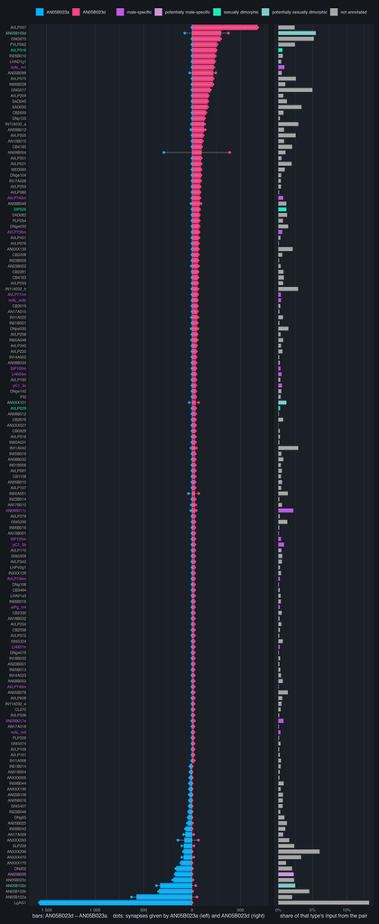

```r
bc_plot(bars_out,
        pair      = PAIR,
        lab_cols  = unname(DIMORPH_COLS[as.character(bars_out$grp)]),
        grp_cols  = DIMORPH_COLS,
        x_lab     = sprintf("bars: %s − %s    dots: synapses given by %s (left) and %s (right)",
                            PAIR[2], PAIR[1], PAIR[1], PAIR[2]),
        share_lab = "share of that type's input from the pair")
```

## Output onto dimorphic partners

Which of the two sends more of its output to partners the dataset calls dimorphic or sex-specific. Computed on `out_diff`, the whole downstream table rather than the `MIN_DIFF` subset, because this is a property of each type’s entire output and thresholding first would drop the tail where an annotated class can hide.

`frac_l` / `frac_r` are shares of that type’s own total, so “more” here survives one of the two simply being the bigger neuron.

```r
dimorph_out <- dimorph_output(out_diff, mba)

dimorph_out
```

| dimorphism | types | total_l | total_r | frac_l | frac_r |
| --- | --- | --- | --- | --- | --- |
| male-specific | 60 | 39 | 1069 | 0.006601219 | 0.0857945425 |
| potentially male-specific | 4 | 175 | 6 | 0.029620853 | 0.0004815409 |
| sexually dimorphic | 18 | 1 | 407 | 0.000169262 | 0.0326645265 |
| potentially sexually dimorphic | 12 | 475 | 509 | 0.080399458 | 0.0408507223 |
| not annotated | 736 | 5218 | 10469 | 0.883209208 | 0.8402086677 |

Total share onto annotated partners, per type:

```r
setNames(colSums(dimorph_out[dimorph_out$dimorphism != "not annotated",
                             c("frac_l", "frac_r")]), PAIR)
```

```
## AN05B023a AN05B023d
## 0.1167908 0.1597913
```

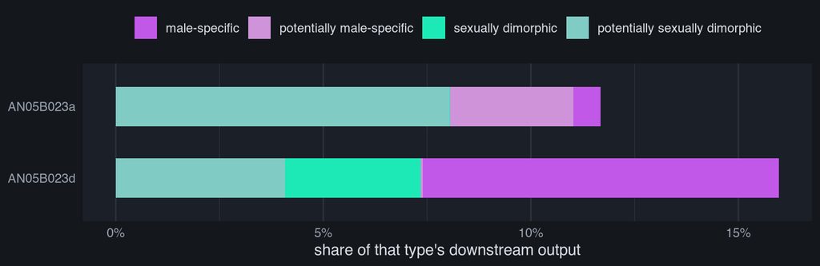

```r
dimorph_output_plot(dimorph_out, PAIR)
```

Read the bar lengths first — that is the answer to “which one” — and the segments only for which class carries it. Note that `not annotated` is the majority class in `mba`, so both bars are short by construction; the comparison is between them, not against 100%.

`09_an05b023_dimorphic.Rmd` puts these two bars next to b and c, and splits them by volume: in the brain AN05B023d gives 21.8% of its output to dimorphic partners against 6.9% for AN05B023a, and in the VNC the order reverses.

## Sensory input to a and d

The mirror image of the plot above, on the types the downstream view excluded: the leg and wing gustatory bristles of `contact_pool`. Left end of each line is what that bristle type gives AN05B023a, right end what it gives AN05B023d, and the bar is still right minus left.

```r
l_input <- type_edges(paste0("/type:", PAIR[1]), "i", contact_pool, sensory = TRUE)
r_input <- type_edges(paste0("/type:", PAIR[2]), "i", contact_pool, sensory = TRUE)

in_diff <- diff_of(l_input, r_input)

in_diff |> select(type, total_l, total_r, diff, frac_diff)
```

| type | total_l | total_r | diff | frac_diff |
| --- | --- | --- | --- | --- |
| WG1 | 2832 | 74 | -2758 | -0.4807742176 |
| LgLG2 | 2272 | 12 | -2260 | -0.3900771533 |
| LgLG4 | 58 | 0 | -58 | -0.0099862259 |
| WG4 | 184 | 135 | -49 | -0.0192219690 |
| LgLG8 | 22 | 2 | -20 | -0.0036033088 |
| LgLG7 | 18 | 0 | -18 | -0.0030991736 |
| LgLG5 | 16 | 13 | -3 | -0.0015551162 |
| SNxxxx | 0 | 10 | 10 | 0.0009228498 |
| SNch05 | 0 | 28 | 28 | 0.0025839793 |
| LgLG6 | 35 | 112 | 77 | 0.0043097465 |

[output cut: 5 more lines]

The second panel inverts too. Downstream it asked what share of the partner’s input comes from the pair; here it asks what share of the bristle type’s whole output lands on them.

No dimorphism colours on this one: every body in the pool is unannotated for `dimorphism`, so that scale would come out uniformly grey. `subclass` is what the pool does carry, so the fill is leg versus wing bristle.

The FOCUS types are picked out in bold rather than in `WEB_PALETTE`, which gives `LgLG1a` and `LgLG1b` the very pink and blue that already mean right and left in this plot. Types are named as the connectome names them, so no receptor-channel grouping is implied.

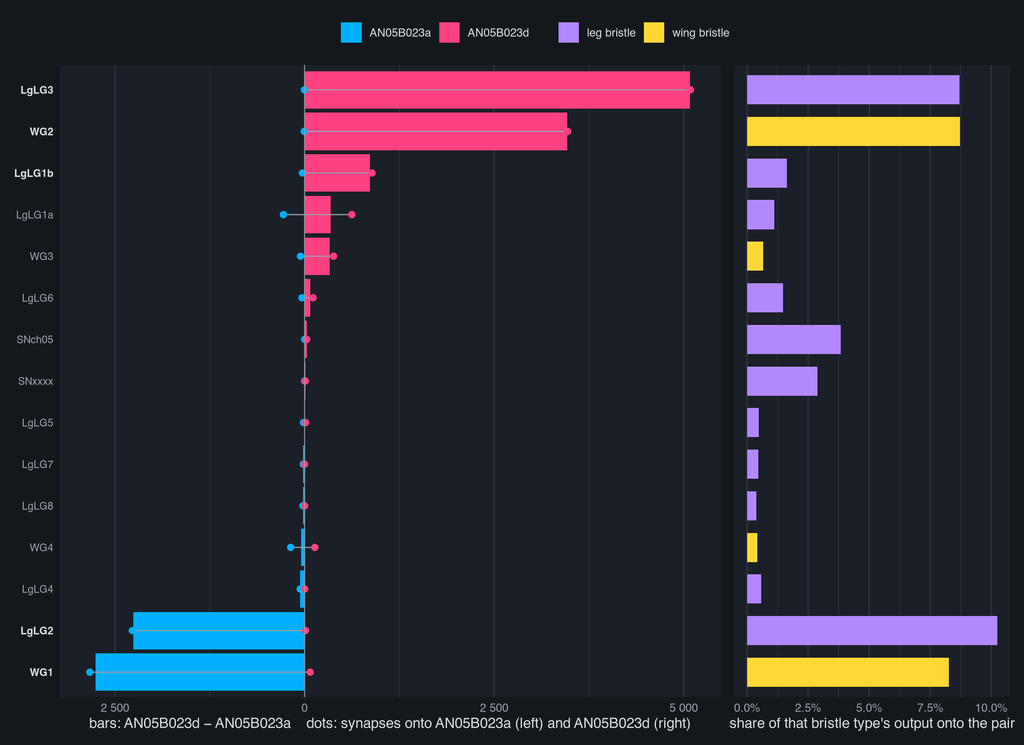

```r
bars_in <- bars_sensory(in_diff, mba, contact_pool)

is_focus <- as.character(bars_in$type) %in% FOCUS

bc_plot(bars_in,
        pair      = PAIR,
        lab_cols  = ifelse(is_focus, DARK_FG, DARK_DIM),
        grp_cols  = SUBCLASS_COLS,
        x_lab     = sprintf("bars: %s − %s    dots: synapses onto %s (left) and %s (right)",
                            PAIR[2], PAIR[1], PAIR[1], PAIR[2]),
        share_lab = "share of that bristle type's output onto the pair",
        lab_face  = ifelse(is_focus, "bold", "plain"))
```